# Emmaus Client Analysis

Peter Kirgis

11/24/2020

##Introduction

This data comes from the non-profit Emmaus, inc. Emmaus is a local homeless shelter and affordable housing developer in Haverhill, MA. I created two datasets, one from 2019 and one from 2020, out of a dozen csvs that contained entry and exit data at the client level for one of the programs at Emmaus, an individual homeless shelter. The appendix at the end contains information about some variables of interest. I was looking to do a few things with the data. First, I wanted to get a sense of the population Emmaus was serving over these years, especially racial demographics. Second, I was interested in finding out what contributes to a client successfully exiting the program into some form of stable, independent housing. Understanding the variables that contribute to these outcomes is key to understanding how Emmaus can target individuals that are most vulnerable while they are at the shelter.

##Part 1: Collect data from SQL Databases

```r
path.to.db <- paste0("/Users/peterkirgis/Documents/DataAnalytics/A+A_Project_draft/")
con <- dbConnect(RSQLite::SQLite(),
                 dbname=paste0(path.to.db,"MitchsFY2020.db"))
dbListTables(con)
client_list <- tbl(con, "client_entry_exit") %>%
  collect

con2 <- dbConnect(RSQLite::SQLite(),
                 dbname=paste0(path.to.db,"MitchsFY2019.db"))
dbListTables(con2)
client_list19 <- tbl(con2, "client_entry_exit") %>%
  collect
```

##Part 2: Clean up categorical fields, manipulate tables for analysis

```r
#convert demographics into categorical variables

client_list$race <- "White"
client_list$race[client_list$BlackAfAmerican==1] <- "African American"
client_list$race[client_list$Asian==1] <- "Asian"
client_list$race[client_list$NativeHIOtherPacific==1] <- "Hawaiian Islander"
client_list$race[client_list$AmIndAKNative==1] <- "Native American"

client_list$Gender[client_list$Gender==1] <- "Male"
client_list$Gender[client_list$Gender==0] <- "Female"
client_list$Gender[client_list$Gender==2] <- "Trans Female"

client_list$Ethnicity[client_list$Ethnicity==1] <- "Hispanic"
client_list$Ethnicity[client_list$Ethnicity==0] <- "Non-Hispanic"

#create age variable and convert destination to categorical

client_list$DOB <- as.Date(client_list$DOB)
client_list$EntryDate <- as.Date(client_list$EntryDate)
client_list$age <- floor(age_calc(client_list$DOB, enddate=client_list$EntryDate, units = "years"))

client_list$Destination_1 <- ""
client_list$Destination_1[client_list$Destination == 13] <- "Staying with Friends, temporary"
client_list$Destination_1[client_list$Destination == 12] <- "Staying with Family, temporary"
client_list$Destination_1[client_list$Destination == 1] <- "Emergency Shelter or Paid Motel"
client_list$Destination_1[client_list$Destination == 6] <- "Hospital, non-psychiatric"
client_list$Destination_1[client_list$Destination == 20] <- "Rental by Client, other subsidy"
client_list$Destination_1[client_list$Destination == 16] <- "Place Not Meant for Habitation"
client_list$Destination_1[client_list$Destination == 10] <- "Rental by Client, no subsidy"
client_list$Destination_1[client_list$Destination == 17] <- "Other"
client_list$Destination_1[client_list$Destination == 7] <- "Prison or Juvenile Detention Facility"
client_list$Destination_1[client_list$Destination == 22] <- "Staying with Family, permanent"
client_list$Destination_1[client_list$Destination == 23] <- "Staying with Friends, permanent"
client_list$Destination_1[client_list$Destination == 25] <- "Nursing Home"
client_list$Destination_1[client_list$Destination == 19] <- "Rental by Client, VASH Subsidy"
client_list$Destination_1[client_list$Destination == 18] <- "Safe Haven"
client_list$Destination_1[client_list$Destination == 2] <- "Transitional Housing"
client_list$Destination_1[client_list$Destination == 4] <- "Psychiatric Hospital"
client_list$Destination_1[client_list$Destination == 5] <- "Substance Abuse Treatment"

#carry out the same operations for 2019 data

client_list19$race <- "White"
client_list19$race[client_list19$BlackAfAmerican==1] <- "African American"
client_list19$race[client_list19$Asian==1] <- "Asian"
client_list19$race[client_list19$NativeHIOtherPacific==1] <- "Hawaiian Islander"
client_list19$race[client_list19$AmIndAKNative==1] <- "Native American"

client_list19$Gender[client_list19$Gender==1] <- "Male"
client_list19$Gender[client_list19$Gender==0] <- "Female"
client_list19$Gender[client_list19$Gender==2] <- "Trans Female"

client_list19$Ethnicity[client_list19$Ethnicity==1] <- "Hispanic"
client_list19$Ethnicity[client_list19$Ethnicity==0] <- "Non-Hispanic"

client_list19$DOB <- as.Date(client_list19$DOB)
client_list19$EntryDate <- as.Date(client_list19$EntryDate)
client_list19$age <- floor(age_calc(client_list19$DOB, enddate=client_list19$EntryDate, units = "years"))

client_list19$Destination_1 <- ""
client_list19$Destination_1[client_list19$Destination == 13] <- "Staying with Friends, temporary"
client_list19$Destination_1[client_list19$Destination == 12] <- "Staying with Family, temporary"
client_list19$Destination_1[client_list19$Destination == 1] <- "Emergency Shelter or Paid Motel"
client_list19$Destination_1[client_list19$Destination == 6] <- "Hospital, non-psychiatric"
client_list19$Destination_1[client_list19$Destination == 20] <- "Rental by Client, other subsidy"
client_list19$Destination_1[client_list19$Destination == 16] <- "Place Not Meant for Habitation"
client_list19$Destination_1[client_list19$Destination == 10] <- "Rental by Client, no subsidy"
client_list19$Destination_1[client_list19$Destination == 17] <- "Other"
client_list19$Destination_1[client_list19$Destination == 7] <- "Prison or Juvenile Detention Facility"
client_list19$Destination_1[client_list19$Destination == 22] <- "Staying with Family, permanent"
client_list19$Destination_1[client_list19$Destination == 23] <- "Staying with Friends, permanent"
client_list19$Destination_1[client_list19$Destination == 25] <- "Nursing Home"
client_list19$Destination_1[client_list19$Destination == 19] <- "Rental by Client, VASH Subsidy"
client_list19$Destination_1[client_list19$Destination == 18] <- "Safe Haven"
client_list19$Destination_1[client_list19$Destination == 2] <- "Transitional Housing"
client_list19$Destination_1[client_list19$Destination == 4] <- "Psychiatric Hospital"
client_list19$Destination_1[client_list19$Destination == 5] <- "Substance Abuse Treatment"

#create table with just data for clients who both entered and exitited

client_entry_exit <- client_list %>%
  filter(Destination != "NA")

client19_entry_exit <- client_list19 %>%
  filter(Destination != "NA")

#code variable for clients who exited into housing

client_entry_exit$Exit_to_housing <- 0
client_entry_exit$Exit_to_housing[client_entry_exit$Destination_1 == "Rental by Client, other subsidy"] <- 1
client_entry_exit$Exit_to_housing[client_entry_exit$Destination_1 == "Rental by Client, no subsidy"] <- 1
client_entry_exit$Exit_to_housing[client_entry_exit$Destination_1 == "Rental by Client, VASH Subsidy"] <- 1
client_entry_exit$Exit_to_housing[client_entry_exit$Destination_1 == "Transitional Housing"] <- 1

client19_entry_exit$Exit_to_housing <- 0
client19_entry_exit$Exit_to_housing[client19_entry_exit$Destination_1 == "Rental by Client, other subsidy"] <- 1
client19_entry_exit$Exit_to_housing[client19_entry_exit$Destination_1 == "Rental by Client, no subsidy"] <- 1
client19_entry_exit$Exit_to_housing[client19_entry_exit$Destination_1 == "Rental by Client, VASH Subsidy"] <- 1
client19_entry_exit$Exit_to_housing[client19_entry_exit$Destination_1 == "Transitional Housing"] <- 1

# create tables for data on entries
onentry <- client_list %>%
  filter(DataCollectionStage == 1)

onentry2 <- client_list19 %>%
  filter(DataCollectionStage == 1)

# create table only for data on exits

client_exit <- client_entry_exit %>%
  filter(DataCollectionStage==3)

client19_exit <- client19_entry_exit %>%
  filter(DataCollectionStage==3)

#create table with exit data combined for two years

client_exit_19_20 <- union(client_exit, client19_exit)
distinct_clients_19_20 <- client_exit_19_20 %>%
  distinct(PersonalID, .keep_all = TRUE)

client_19_20 <- union(client_list, client_list19)
client_19_20 <- client_19_20 %>%
  distinct(PersonalID, DataCollectionStage, .keep_all = TRUE) %>%
  filter(DataCollectionStage != 5)
```

##Part 3: Create tables and charts to show breakdowns along key variables

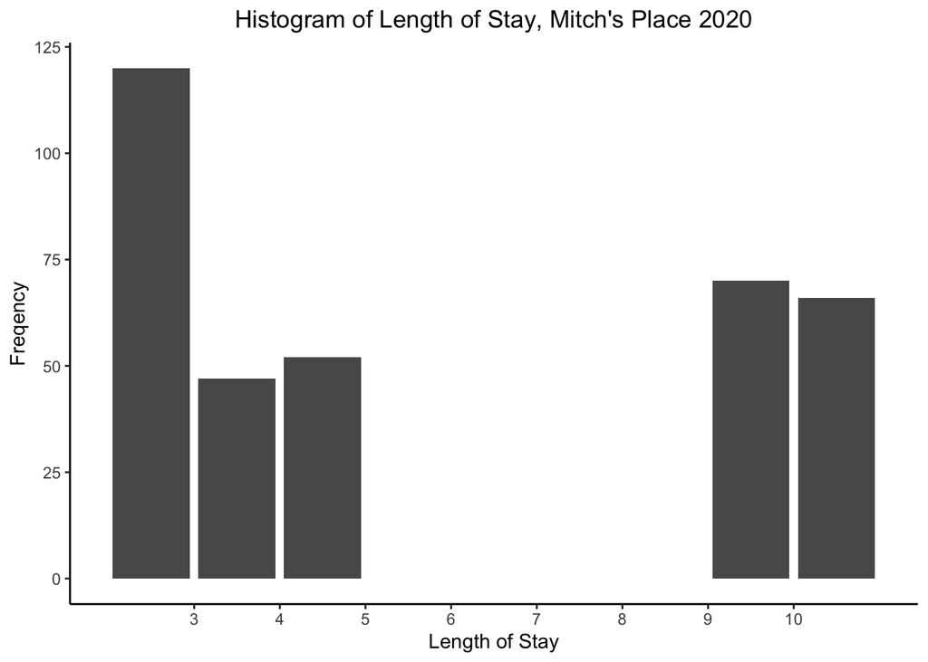

```r
#2020
dens <- density(onentry$LengthOfStay)
df <- data.frame(x=dens$x, y=dens$y)
probs <- c(0.1, 0.25, 0.5, 0.75, 0.9)
quantiles <- quantile(onentry$LengthOfStay, prob=probs)
df$quant <- factor(findInterval(df$x,quantiles))
ggplot(onentry, aes(x=LengthOfStay)) + geom_bar() +
scale_x_binned() + ylab("Freqency") + xlab("Length of Stay") + ggtitle("Histogram of Length of Stay, Mitch's Place 2020") + theme_classic() +
  theme(plot.title = element_text(hjust = 0.5))
```

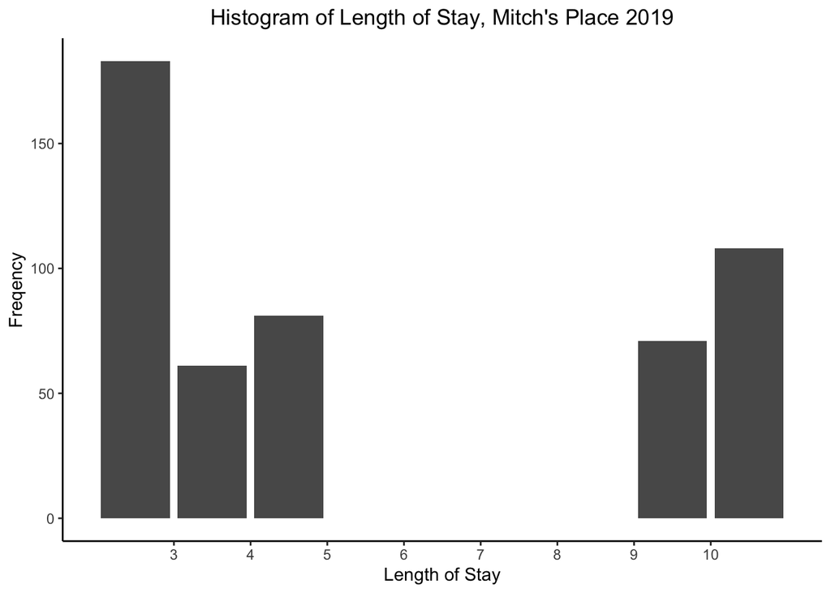

```r
#2019
dens <- density(onentry2$LengthOfStay)
df <- data.frame(x=dens$x, y=dens$y)
probs <- c(0.1, 0.25, 0.5, 0.75, 0.9)
quantiles <- quantile(onentry2$LengthOfStay, prob=probs)
df$quant <- factor(findInterval(df$x,quantiles))
ggplot(onentry2, aes(x=LengthOfStay)) + geom_bar() +
scale_x_binned() + ylab("Freqency") + xlab("Length of Stay") + ggtitle("Histogram of Length of Stay, Mitch's Place 2019") + theme_classic() +
  theme(plot.title = element_text(hjust = 0.5))
```

```r
#2020
tb <- table(onentry$race)
tb
```

```
##
##  African American Hawaiian Islander   Native American             White
##                26                 2                 5               322
```

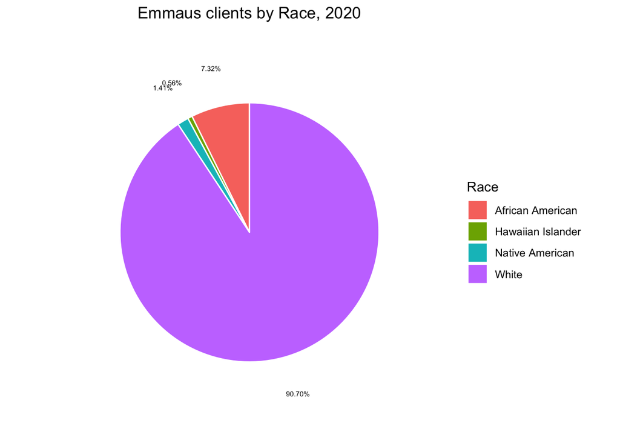

```r
race.df <- as.data.frame(tb, stringsAsFactors = FALSE)
names(race.df) <- c("Race", "Frequency")
race.df <- race.df %>%
  mutate(per=Frequency/sum(Frequency))
race.df$label <- scales::percent(race.df$per)
ggplot(race.df, aes(x="", y=per, fill=Race)) +
  geom_bar(stat="identity", width=1, color='white') +
  coord_polar("y", start=0) + theme_void() + ggtitle("Emmaus clients by Race, 2020") +theme(plot.title = element_text(hjust = 0.5)) + geom_text(size=2, aes(x=1.8, y = per, label=label), position = position_stack(vjust=0.5))
```

```r
#2019
tb <- table(onentry2$race)
tb
```

```
##
##  African American             Asian Hawaiian Islander   Native American
##                47                 1                 7                 7
##             White
##               442
```

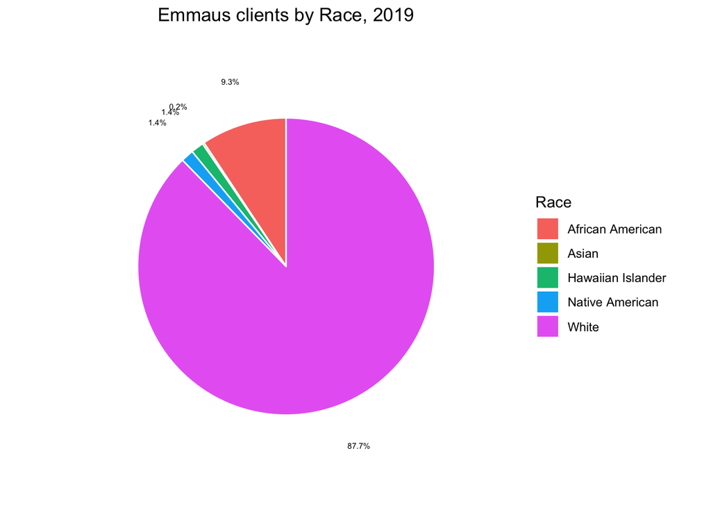

```r
race.df <- as.data.frame(tb, stringsAsFactors = FALSE)
names(race.df) <- c("Race", "Frequency")
race.df <- race.df %>%
  mutate(per=Frequency/sum(Frequency))
race.df$label <- scales::percent(race.df$per)
ggplot(race.df, aes(x="", y=per, fill=Race)) +
  geom_bar(stat="identity", width=1, color='white') +
  coord_polar("y", start=0) + theme_void() + ggtitle("Emmaus clients by Race, 2019") + theme(plot.title = element_text(hjust = 0.5)) + geom_text(size=2, aes(x=1.8, y = per, label=label), position = position_stack(vjust=0.5))
```

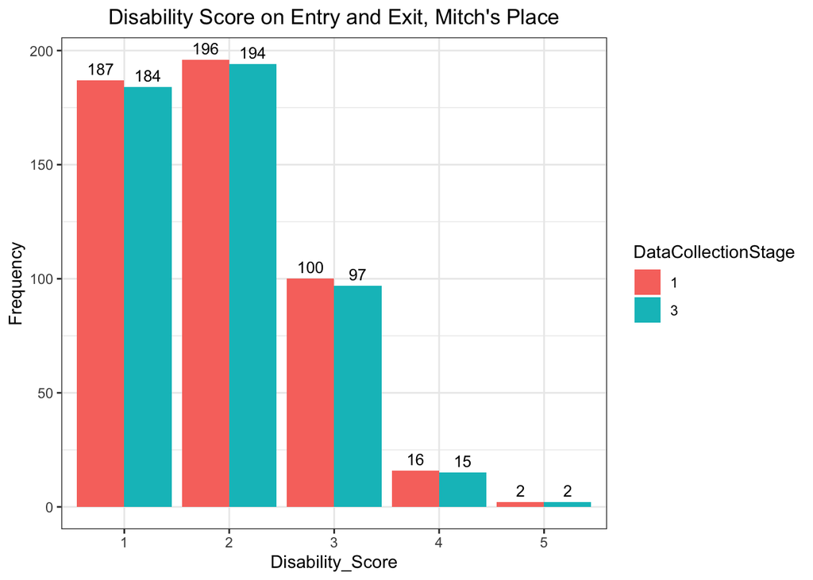

```r
tb <- table(client_19_20$client_disability_score, client_19_20$DataCollectionStage)
disabilityscore.df <- as.data.frame(tb, stringsAsFactors = FALSE)
names(disabilityscore.df) <- c("Disability_Score", "DataCollectionStage", "Frequency")
ggplot(disabilityscore.df, aes(x=Disability_Score, y=Frequency, fill=DataCollectionStage)) + geom_col(position = 'dodge') + theme_bw() + geom_text(aes(label=Frequency), vjust=-0.5, color="black",
            position = position_dodge(0.9), size=3.5) + ggtitle("Disability Score on Entry and Exit, Mitch's Place") + theme(plot.title = element_text(hjust = 0.5))
```

```r
#tabulation of race with outcomes

table(distinct_clients_19_20$race, distinct_clients_19_20$Exit_to_housing)
```

```
##
##                       0   1
##   African American   41   8
##   Asian               1   0
##   Hawaiian Islander   3   3
##   Native American     8   0
##   White             430  55
```

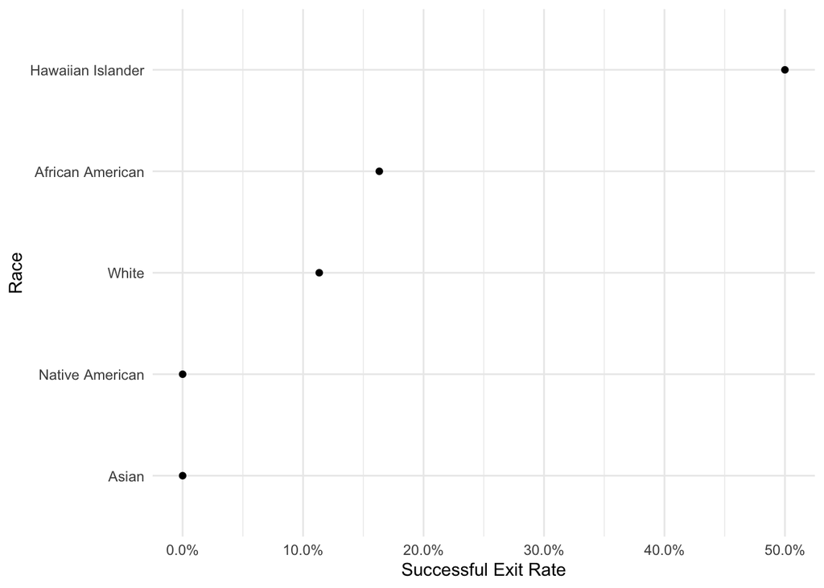

```r
distinct_clients_19_20 %>%
  group_by(race) %>%
  summarize(mean_exit_housing = mean(Exit_to_housing)) %>%
  mutate(race = fct_reorder(race,mean_exit_housing)) %>%
  ggplot(aes(x=mean_exit_housing, y=race)) +
  geom_point() +
  theme_minimal() +
  labs(x="Successful Exit Rate", y="Race") +
  scale_x_continuous(label=percent)
```

```r
distinct_clients_19_20 <- distinct_clients_19_20 %>%
  mutate(race_fct = fct_reorder(race,Exit_to_housing,mean)) %>%
  mutate(Gender_fct = fct_reorder(Gender,Exit_to_housing,mean)) %>%
  mutate(Ethnicity_fct = fct_reorder(Ethnicity,Exit_to_housing,mean))
glmrace <- glm(Exit_to_housing ~ race_fct, data=distinct_clients_19_20, family="binomial")
summ(glmrace)
```

| Observations | 549 |
| --- | --- |
| Dependent variable | Exit_to_housing |
| Type | Generalized linear model |
| Family | binomial |
| Link | logit |

| 𝛘²(4) | 8.47 |
| --- | --- |
| Pseudo-R² (Cragg-Uhler) | 0.03 |
| Pseudo-R² (McFadden) | 0.02 |
| AIC | 404.89 |
| BIC | 426.44 |

|  | Est. | S.E. | z val. | p |
| --- | --- | --- | --- | --- |
| (Intercept) | -16.57 | 2399.54 | -0.01 | 0.99 |
| race_fctNative American | -0.00 | 2545.10 | -0.00 | 1.00 |
| race_fctWhite | 14.51 | 2399.54 | 0.01 | 1.00 |
| race_fctAfrican American | 14.93 | 2399.54 | 0.01 | 1.00 |
| race_fctHawaiian Islander | 16.57 | 2399.54 | 0.01 | 0.99 |

Standard errors: MLE

##Part 4: Logitistic Regression with controls

```r
glm1 <- glm(Exit_to_housing ~ age + MonthsHomelessPastThreeYears + TimesHomelessPastThreeYears + LengthOfStay + Gender_fct + DomesticViolenceVictim + client_disability_score, data=distinct_clients_19_20, family="binomial")
summ(glm1)
```

| Observations | 492 (57 missing obs. deleted) |
| --- | --- |
| Dependent variable | Exit_to_housing |
| Type | Generalized linear model |
| Family | binomial |
| Link | logit |

| 𝛘²(8) | 31.88 |
| --- | --- |
| Pseudo-R² (Cragg-Uhler) | 0.12 |
| Pseudo-R² (McFadden) | 0.09 |
| AIC | 343.01 |
| BIC | 380.79 |

|  | Est. | S.E. | z val. | p |
| --- | --- | --- | --- | --- |
| (Intercept) | -11.97 | 1013.27 | -0.01 | 0.99 |
| age | 0.03 | 0.01 | 2.61 | 0.01 |
| MonthsHomelessPastThreeYears | -0.01 | 0.03 | -0.40 | 0.69 |
| TimesHomelessPastThreeYears | -0.30 | 0.17 | -1.76 | 0.08 |
| LengthOfStay | 0.03 | 0.04 | 0.77 | 0.44 |
| Gender_fctMale | 11.00 | 1013.26 | 0.01 | 0.99 |
| Gender_fctFemale | 11.50 | 1013.26 | 0.01 | 0.99 |
| DomesticViolenceVictim | -1.85 | 0.64 | -2.89 | 0.00 |
| client_disability_score | -0.22 | 0.19 | -1.15 | 0.25 |

Standard errors: MLE

```r
1-pchisq(356.89-327.33, df=7)
```

```
## [1] 0.0001143255
```

```r
rb.fit <- tidy(glm1) %>%
  mutate(exp_estimate = exp(estimate),
         logodds = exp_estimate/(1+exp_estimate),
         lb = exp(estimate - 2*std.error),
         ub = exp(estimate + 2*std.error))
```

```r
tbl <- table(distinct_clients_19_20$DomesticViolenceVictim, distinct_clients_19_20$Exit_to_housing)
rownames(tbl) <- c("No Domestic Violence","Domestic Violence Victim")
colnames(tbl) <- c("Not Placed into Housing","Placed into Housing")
knitr::kable(tbl)
```

|  | Not Placed into Housing | Placed into Housing |
| --- | --- | --- |
| No Domestic Violence | 378 | 63 |
| Domestic Violence Victim | 105 | 3 |

```r
tbl <- table(distinct_clients_19_20$Gender, distinct_clients_19_20$DomesticViolenceVictim)
colnames(tbl) <- c("No Domestic Violence","Domestic Violence Victim")
knitr::kable(tbl)
```

|  | No Domestic Violence | Domestic Violence Victim |
| --- | --- | --- |
| Female | 101 | 78 |
| Male | 340 | 28 |
| Trans Female | 0 | 2 |

##Part 5: APPENDIX *EnrollmentID: specific to an enrollment date and client, used to merge data together* PersonalID: distinct to the client, NOT the enrollment date *DataCollectionStage: when the data was collected, encoded 1 for entry and 3 for exit* LengthOfStay: calculated in months *LivingSituation: where are they coming from, numeric matches to types of locations (not used for this analysis)* Destionation: where did the client exit to, see code for translation to place names *DomesticViolenceVictim: variable that takes 1 if client is victim, 0 otherwise* client_disability_score: a variable I created using an aggregate for each client of mental and physcial disabilities, as well as substance abuse. Each yes answer to a question in the disability survey gains the client a 1, and the disability score is the cumulative sum of all the yes answers. Thus, a higher disability score means more issues for the client.